# Application of SCEPTRE to a small example dataset

Tim Barry, Gene Katsevich, Kathryn Roeder

This vignette illustrates the application of SCEPTRE to a small single-cell CRISPR screen dataset. Our data come from the study A Genome-wide Framework for Mapping Gene Regulation via Cellular Genetic Screens, published by Gasperini et al. in 2019. The authors used CRISPR to perturb candidate enhancers and assessed the impact of these perturbations via scRNA-seq. Our goal in this vignette is to determine the impact of a single perturbation on a single gene, accounting for appropriate technical factors. The gRNA (ID: chr7.3255_top_two) and gene (ID: ENSG00000164713) that we investigate were selected from the set of all perturbations and genes in the Gasperini dataset.

In our analysis of the Gasperini data in Katsevich et al. 2020, we processed all gene-gRNA pairs simultaneously. This large-scale approach allowed us to (i) regularize the negative binomial regression test statistic by pooling information across genes, and (ii) recycle certain repetitive computations, thereby accelerating program execution. This small-scale example serves as a useful demonstration of SCEPTRE, but it does not reflect how one would apply SCEPTRE in practice. Please see the [Github](https://github.com/Timothy-Barry/SCEPTRE) repository for information on reproducing the large-scale analysis reported in Katsevich et al. 2020.

We begin by loading the package and data.

```r
if (!("sceptre" %in% rownames(installed.packages()))) { # check if sceptre is installed
  library(devtools)
  install_github(repo="Timothy-Barry/SCEPTRE", subdir="sceptre_package/sceptre")
}
library(sceptre)
data("expressions")
data("gRNA_indicators")
data("covariate_matrix")
```

The *expressions* vector contains the gene expressions (in UMIs); the *gRNA_indicator* vector records whether the gRNA was present or absent in a given cell; and the *covariate_matrix* records cell-specific technical factors (fraction of UMIs that map to mitochondrial genes, sequencing batch, log-transformed total UMI count across genes, log-transformed total number of detected gRNAs, and log-transformed total genes expressed). There are 205,797 cells in the data. Let’s take a peek at the data by calling *head*.

```r
head(expressions)
```

```
#> [1] 0 3 2 4 0 2
```

```r
head(gRNA_indicators)
```

```
#> [1] 0 0 0 0 0 0
```

```r
head(covariate_matrix)
```

```
#>        p_mito   prep_batch lg_total_umis lg_guide_count lg_n_genes
#> 1 0.058786706 prep_batch_1      9.774062       4.204693   8.174421
#> 2 0.036086518 prep_batch_1      9.096387       3.258097   7.841100
#> 3 0.069823051 prep_batch_1      9.591308       4.110874   8.068090
#> 4 0.026186508 prep_batch_1     10.034428       3.663562   8.420462
#> 5 0.007991318 prep_batch_1      9.223849       3.610918   7.865188
#> 6 0.022356681 prep_batch_1      9.185125       4.043051   7.690286
```

Next, we run the SCEPTRE algorithm by calling the function *run_sceptre_gRNA_gene_pair*. This function returns a *p*-value corresponding to the null hypothesis that the perturbation does not impact gene expression, accounting for the technical factors. This function is for illustration purposes only. When analyzing a large dataset consisting of many gene-gRNA pairs, we would leverage other sceptre functions that more efficiently recycle computation.

```r
result <- run_sceptre_gRNA_gene_pair(expressions = expressions,
                                      gRNA_indicators = gRNA_indicators,
                                      covariate_matrix = covariate_matrix,
                                      B = 1000,
                                      seed = 1234,
                                      reduced_output = FALSE)
```

```
#> Running gRNA precomputation.
#> Running gene precomputation.
#> Running resample 100/1000.
#> Running resample 200/1000.
#> Running resample 300/1000.
#> Running resample 400/1000.
#> Running resample 500/1000.
#> Running resample 600/1000.
#> Running resample 700/1000.
#> Running resample 800/1000.
#> Running resample 900/1000.
#> Running resample 1000/1000.
```

We can examine the *p*-value.

```r
result$p_value
```

```
#> [1] 0.2138241
```

We can examine the negative binomial z-score and the parameters of the fitted skew-t distribution used to compute the *p*-value.

```r
result$z_value
```

```
#> [1] -0.3037842
```

```r
result$skew_t_mle
```

```
#>            xi         omega         alpha            nu
#> -6.563831e-02  1.242149e+00  8.000418e-01  1.185023e+06
```

Finally, we can create a histogram of the resampled, null z-scores.

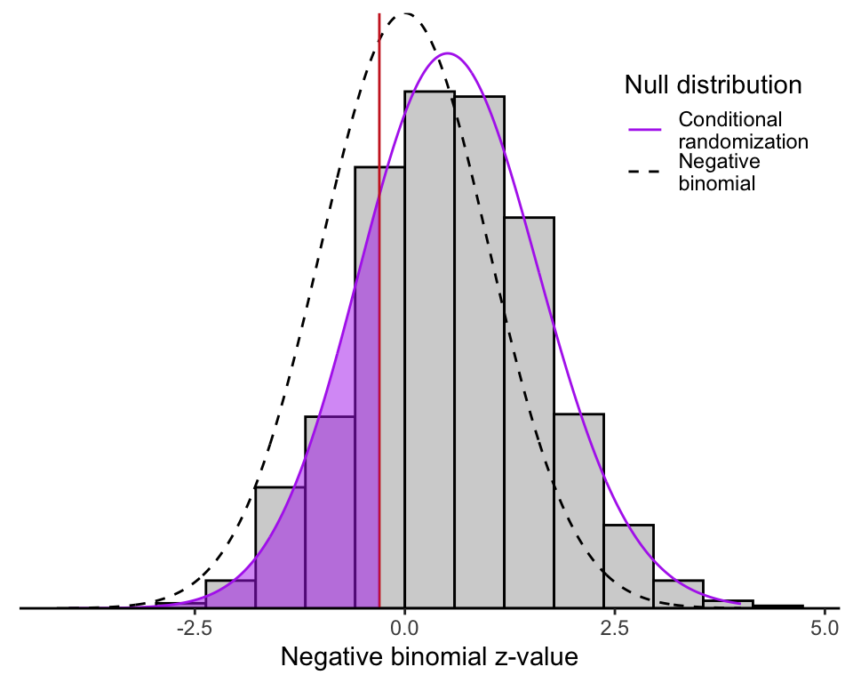

```r
p <- plot_skew_t(resampled_zvalues = result$resampled_z_values, original_zvalue = result$z_value, dp = result$skew_t_mle, interval = c(-4,4))
plot(p)
```

Given that the computed *p*-value (*p* = 0.21) exceeds our pre-chosen significance threshold of 0.05, we retain our null hypothesis that the perturbation does not affect gene expression. In practice, when analyzing a large dataset, we would apply a Benjamini-Hochberg correction to all gene-gRNA pairs and use a more conservative threshold to determine significance.